# PCA + MLP vs End-to-End CNN for Object Localization

## ECE-4563 Machine Learning Project — NYU Tandon

Group member: Yanbo (Bob) Wang, Peijie (Max) Ma

### Project Goal

This project investigates **two fundamentally different learning paradigms** for object localization:

- **Classical pipeline:** PCA for dimensionality reduction followed by an **MLP regressor**
- **End-to-end deep learning:** A **CNN regressor** trained directly on images

Both models predict a **bounding box** around a digit placed on a synthetic MNIST canvas.

### Task Definition

- **Input:** 64×64 grayscale image
- **Output:** Bounding box parameters  
  [ (x_c, y_c, w, h) ] where all values are **normalized to [0,1]**

### Evaluation Metrics

- **Mean Squared Error (MSE)** — regression accuracy
- **Intersection-over-Union (IoU)** — localization quality

A **K-Fold Cross-Validation** procedure is used to rigorously optimize PCA dimensionality.

```python
# --- 1) Imports and Environment Setup ---
import os
import random
import numpy as np
import matplotlib.pyplot as plt

from sklearn.decomposition import PCA
from sklearn.model_selection import train_test_split
from sklearn.preprocessing import StandardScaler

import torch
import torch.nn as nn
import torch.optim as optim
from torch.utils.data import Dataset, DataLoader

from torchvision.datasets import MNIST
from torchvision import transforms
```

## 1.1 Reproducibility and Device Configuration

To ensure **scientific reproducibility**, we fix all random seeds across:

- Python random
- NumPy
- PyTorch (CPU & GPU)

The code automatically detects and uses a **GPU if available**.

```python
def set_seed(seed=42):
    random.seed(seed)
    np.random.seed(seed)
    torch.manual_seed(seed)
    torch.cuda.manual_seed_all(seed)

set_seed(42)
device = torch.device("cuda" if torch.cuda.is_available() else "cpu")
print("Device:", device)
print("-" * 50)
```

```
Device: cpu
--------------------------------------------------
```

# 2. Core Utilities: Bounding Boxes and Data Generation

This section defines:

- Bounding box conversions
- IoU computation
- Synthetic MNIST-on-Canvas generation

```python
def bbox_xywh_to_xyxy(b):
    """ (xc,yc,w,h) normalized -> (x1,y1,x2,y2) normalized """
    xc, yc, w, h = b.T
    x1 = xc - w / 2
    y1 = yc - h / 2
    x2 = xc + w / 2
    y2 = yc + h / 2
    return np.stack([x1, y1, x2, y2], axis=1)
```

### Intersection-over-Union (IoU)

IoU measures the **overlap ratio** between predicted and ground-truth boxes: $ \text{IoU} = \frac{\text{Area of Intersection}}{\text{Area of Union}} $

```python
def compute_iou(a, b):
    ax1, ay1, ax2, ay2 = a.T
    bx1, by1, bx2, by2 = b.T

    ix1 = np.maximum(ax1, bx1)
    iy1 = np.maximum(ay1, by1)
    ix2 = np.minimum(ax2, bx2)
    iy2 = np.minimum(ay2, by2)

    iw = np.maximum(0, ix2 - ix1)
    ih = np.maximum(0, iy2 - iy1)
    inter = iw * ih

    area_a = (ax2 - ax1) * (ay2 - ay1)
    area_b = (bx2 - bx1) * (by2 - by1)
    union = area_a + area_b - inter + 1e-9
    return inter / union
```

### Synthetic MNIST-on-Canvas Generator

```python
def generate_sample(digit, canvas_size=64):
    canvas = np.zeros((canvas_size, canvas_size), dtype=np.float32)
    scale = np.random.uniform(0.6, 1.0)
    size = int(round(28 * scale))
    size = max(8, size)
    resized = digit[:size, :size]

    top = np.random.randint(0, canvas_size - size)
    left = np.random.randint(0, canvas_size - size)

    canvas[top:top+size, left:left+size] = resized

    xc = (left + size / 2) / canvas_size
    yc = (top + size / 2) / canvas_size
    w = size / canvas_size
    h = size / canvas_size

    return canvas, np.array([xc, yc, w, h], dtype=np.float32)
```

## 2.1 Dataset Construction

We generate a **large synthetic dataset** using MNIST digits. This avoids annotation noise while preserving realism.

```python
def load_dataset(n_samples=8000, data_dir="./data"):
    print(f"Loading/Generating {n_samples} samples...")
    mnist = MNIST(data_dir, train=True, download=True, transform=transforms.ToTensor())

    X = np.zeros((n_samples, 1, 64, 64), dtype=np.float32)
    y = np.zeros((n_samples, 4), dtype=np.float32)

    for i in range(n_samples):
        img, _ = mnist[random.randint(0, len(mnist) - 1)]
        digit = img.squeeze().numpy().astype(np.float32)
        canvas, bbox = generate_sample(digit)
        X[i, 0] = canvas
        y[i] = bbox
    return X, y
```

# 3. Dataset Wrappers and Model Definitions

We define **two learning pipelines**:

### Model 1 — PCA + MLP

- Flatten image
- Standardize
- Reduce dimension via PCA
- Predict bounding box using MLP

### Model 2 — CNN

- End-to-end learning from raw pixels
- Convolutional feature extraction
- Fully-connected regression head

```python
class ImageDataset(Dataset):
    def __init__(self, X, y):
        self.X = torch.from_numpy(X).float()
        self.y = torch.from_numpy(y).float()
    def __len__(self): return len(self.X)
    def __getitem__(self, i): return self.X[i], self.y[i]
class PCADataset(Dataset):
    def __init__(self, Z, y):
        self.Z = torch.from_numpy(Z).float()
        self.y = torch.from_numpy(y).float()
    def __len__(self): return len(self.Z)
    def __getitem__(self, i): return self.Z[i], self.y[i]
```

### MLP Regressor Architecture

- Input: PCA features
- Two hidden layers
- Sigmoid output to enforce valid box range

```python
class MLPRegressor(nn.Module):
    def __init__(self, in_features=128):
        super().__init__()
        self.net = nn.Sequential(
            nn.Linear(in_features, 256),
            nn.ReLU(),
            nn.Dropout(0.1),
            nn.Linear(256, 256),
            nn.ReLU(),
            nn.Linear(256, 4),
            nn.Sigmoid()
        )
    def forward(self, x):
        return self.net(x)
```

### CNN Regressor Architecture

- Progressive spatial downsampling
- Adaptive pooling for shape invariance
- Fully connected regression head

```python
class CNNRegressor(nn.Module):
    def __init__(self):
        super().__init__()
        self.conv = nn.Sequential(
            nn.Conv2d(1, 16, 5, stride=2, padding=2),
            nn.ReLU(),
            nn.Conv2d(16, 32, 3, stride=2, padding=1),
            nn.ReLU(),
            nn.Conv2d(32, 64, 3, stride=2, padding=1),
            nn.ReLU(),
            nn.AdaptiveAvgPool2d((4, 4))
        )
        self.fc = nn.Sequential(
            nn.Flatten(),
            nn.Linear(64 * 4 * 4, 128),
            nn.ReLU(),
            nn.Linear(128, 4),
            nn.Sigmoid()
        )
    def forward(self, x):
        return self.fc(self.conv(x))
```

# 4. Training and Evaluation Logic

Both models:

- Use **Mean Squared Error loss**
- Are evaluated using **IoU on the test set**

```python
def train_one_epoch(model, loader, optimizer, device):
    model.train()
    loss_fn = nn.MSELoss()
    total_loss = 0.0

    for x, y in loader:
        x, y = x.to(device), y.to(device)
        optimizer.zero_grad()
        loss = loss_fn(model(x), y)
        loss.backward()
        optimizer.step()
        total_loss += loss.item() * x.size(0)

    return total_loss / len(loader.dataset)
```

```python
@torch.no_grad()
def evaluate(model, loader, device):
    model.eval()
    preds, gts = [], []

    for x, y in loader:
        pred = model(x.to(device)).cpu().numpy()
        preds.append(pred)
        gts.append(y.numpy())

    P = np.vstack(preds)
    G = np.vstack(gts)

    mse = float(np.mean((P - G) ** 2))
    iou = float(compute_iou(
        bbox_xywh_to_xyxy(P),
        bbox_xywh_to_xyxy(G)
    ).mean())
    return mse, iou, P, G
```

# 5. Main Execution

## PCA Component Optimization (K-Fold CV) and CNN Training

This section contains the **core experimental pipeline** of the project.

We perform:

- **(A) PCA + MLP pipeline** with rigorous **K-Fold Cross-Validation**
- **(B) End-to-End CNN training** on the same data split

A strict **pool / test split** is enforced to avoid data leakage.

```python
# --- 5) Main Execution: (A) PCA Component Optimization (K-Fold CV) + (B) CNN Training ---

from sklearn.model_selection import KFold
```

## 5.0 Experimental Configuration

Key hyperparameters used consistently across all experiments:

- **N_SAMPLES**: Total synthetic dataset size
- **PCA_GRID**: Candidate PCA dimensions
- **CV_EPOCHS**: Short training during cross-validation
- **FINAL_EPOCHS**: Full training for final evaluation
- **N_SPLITS**: Number of folds in K-Fold CV

```python
# =========================
# 5.0) Configuration
# =========================
N_SAMPLES = 8000
BATCH_SIZE = 128

PCA_GRID = [16, 32, 64, 128, 256, 512]

CV_EPOCHS = 5       # epochs per fold during CV (speed)
FINAL_EPOCHS = 10   # epochs for final models

N_SPLITS = 5        # k-fold splits
```

## 5.1 Data Loading and Pool/Test Split

We split the dataset into:

- **Pool set (80%)**: used for PCA cross-validation and final training
- **Test set (20%)**: strictly held out for final evaluation

The test set is **never used** during PCA selection.

```python
# 5.1) Data Loading + Pool/Test Split

X, y = load_dataset(n_samples=N_SAMPLES)

# Hold-out TEST set (never used during CV)
X_pool, X_test, y_pool, y_test = train_test_split(X, y, test_size=0.2, random_state=42)

print(f"Pool/Test: {len(X_pool)} / {len(X_test)}")

# Pre-flatten pool once for PCA pipeline in CV
X_pool_flat = X_pool.reshape(len(X_pool), -1).astype(np.float32)
y_pool = y_pool.astype(np.float32)
y_test = y_test.astype(np.float32)
```

```
Loading/Generating 8000 samples...
Pool/Test: 6400 / 1600
```

## 5.2 PCA Component Optimization via K-Fold Cross-Validation (PCA + MLP)

### Why K-Fold CV?

- Prevents **overfitting** to a single split
- Provides **mean ± std** performance estimates
- Ensures **no preprocessing leakage**

Important:  
**StandardScaler and PCA are fit only on the training split of each fold.**

```python
# 5.2) (A) PCA Components Optimization via K-Fold CV (PCA+MLP)

def run_cv_for_k(Xflat, y, k, n_splits=5, seed=42):
    """
    Returns mean_mse, std_mse, mean_iou, std_iou over folds for given PCA component count k.
    No leakage: scaler + PCA are fit ONLY on each fold's training split.
    """
    kf = KFold(n_splits=n_splits, shuffle=True, random_state=seed)

    fold_mses, fold_ious = [], []

    for fold, (tr_idx, va_idx) in enumerate(kf.split(Xflat), start=1):
        Xtr, Xva = Xflat[tr_idx], Xflat[va_idx]
        ytr, yva = y[tr_idx], y[va_idx]

        # Fit preprocessing on fold-train only
        scaler = StandardScaler()
        Xtr_s = scaler.fit_transform(Xtr)
        Xva_s = scaler.transform(Xva)

        pca = PCA(n_components=k, random_state=seed)
        Ztr = pca.fit_transform(Xtr_s).astype(np.float32)
        Zva = pca.transform(Xva_s).astype(np.float32)

        # Train MLP on PCA features
        mlp = MLPRegressor(in_features=k).to(device)
        opt = optim.Adam(mlp.parameters(), lr=1e-3)

        tr_loader = DataLoader(PCADataset(Ztr, ytr), batch_size=BATCH_SIZE, shuffle=True)
        va_loader = DataLoader(PCADataset(Zva, yva), batch_size=BATCH_SIZE, shuffle=False)

        for _ in range(CV_EPOCHS):
            train_one_epoch(mlp, tr_loader, opt, device)

        mse, iou, _, _ = evaluate(mlp, va_loader, device)
        fold_mses.append(mse)
        fold_ious.append(iou)

    return (float(np.mean(fold_mses)), float(np.std(fold_mses)),
            float(np.mean(fold_ious)), float(np.std(fold_ious)))
```

### Cross-Validation Results over PCA_GRID

We evaluate each PCA dimension using:

- **Mean IoU** (primary selection metric)
- **Mean MSE** (regression accuracy)

The best PCA dimension is selected **by highest mean IoU**.

```python
print(f"(A) PCA Optimization: {N_SPLITS}-Fold CV over PCA_GRID")
cv_results = []  # (k, mean_mse, std_mse, mean_iou, std_iou)

for k in PCA_GRID:
    mean_mse, std_mse, mean_iou, std_iou = run_cv_for_k(
        X_pool_flat, y_pool, k, n_splits=N_SPLITS, seed=42
    )
    cv_results.append((k, mean_mse, std_mse, mean_iou, std_iou))
    print(f"k={k:4d} | CV IoU={mean_iou:.4f} ± {std_iou:.4f} | CV MSE={mean_mse:.6f} ± {std_mse:.6f}")
```

```
(A) PCA Optimization: 5-Fold CV over PCA_GRID
k=  16 | CV IoU=0.6346 ± 0.0069 | CV MSE=0.003049 ± 0.000156
k=  32 | CV IoU=0.7525 ± 0.0030 | CV MSE=0.001253 ± 0.000038
k=  64 | CV IoU=0.7561 ± 0.0044 | CV MSE=0.001204 ± 0.000070
k= 128 | CV IoU=0.7471 ± 0.0043 | CV MSE=0.001254 ± 0.000045
k= 256 | CV IoU=0.7400 ± 0.0059 | CV MSE=0.001349 ± 0.000074
k= 512 | CV IoU=0.7324 ± 0.0048 | CV MSE=0.001427 ± 0.000054
```

### PCA Dimension Selection

The optimal PCA dimension is chosen as: $$ k^* = \arg\max_{k} \overline{\text{IoU}}_k $$

```python
# Choose best k by mean IoU
best = max(cv_results, key=lambda t: t[3])  # mean_iou
best_k, best_mse, best_mse_std, best_iou, best_iou_std = best


print(f"Best k by CV mean IoU: k={best_k} (IoU={best_iou:.4f} ± {best_iou_std:.4f}, "
      f"MSE={best_mse:.6f} ± {best_mse_std:.6f})")
```

```
Best k by CV mean IoU: k=64 (IoU=0.7561 ± 0.0044, MSE=0.001204 ± 0.000070)
```

### Cross-Validation Performance Curves

We visualize:

- **MSE vs PCA dimension**
- **IoU vs PCA dimension**

Error bars represent **±1 standard deviation** across folds.

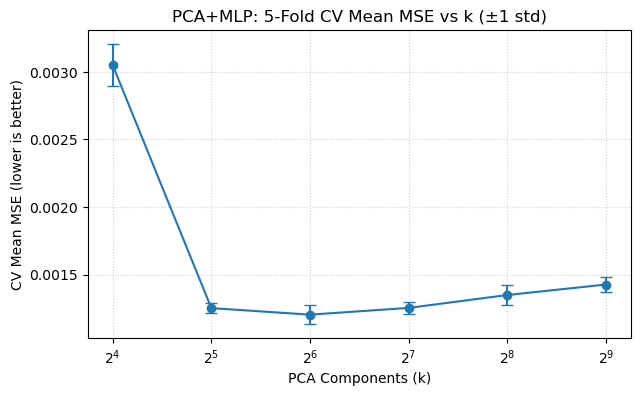

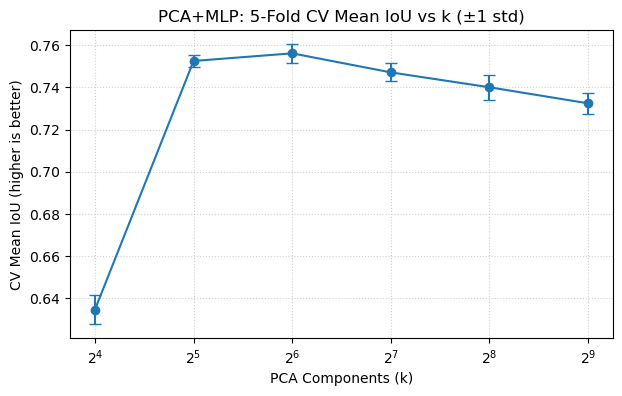

```python
# Plot CV curves with variation bars
cv_sorted = sorted(cv_results, key=lambda t: t[0])
ks       = [t[0] for t in cv_sorted]
mses     = [t[1] for t in cv_sorted]
mses_std = [t[2] for t in cv_sorted]
ious     = [t[3] for t in cv_sorted]
ious_std = [t[4] for t in cv_sorted]

plt.figure(figsize=(7, 4))
plt.errorbar(ks, mses, yerr=mses_std, marker="o", capsize=4)
plt.xlabel("PCA Components (k)")
plt.ylabel("CV Mean MSE (lower is better)")
plt.title(f"PCA+MLP: {N_SPLITS}-Fold CV Mean MSE vs k (±1 std)")
plt.grid(True, linestyle=":", alpha=0.6)
plt.xscale("log", base=2)
plt.show()

plt.figure(figsize=(7, 4))
plt.errorbar(ks, ious, yerr=ious_std, marker="o", capsize=4)
plt.xlabel("PCA Components (k)")
plt.ylabel("CV Mean IoU (higher is better)")
plt.title(f"PCA+MLP: {N_SPLITS}-Fold CV Mean IoU vs k (±1 std)")
plt.grid(True, linestyle=":", alpha=0.6)
plt.xscale("log", base=2)
plt.show()
```

## 5.3 Final Training and Evaluation: PCA + MLP

Using the **optimal PCA dimension**, we:

- Retrain on the **entire pool set**
- Evaluate once on the **held-out test set**

```python
# 5.3) Final Train/Eval for PCA+MLP using best_k (on TEST)

print(f"Final PCA+MLP Training on FULL POOL with k={best_k}")
# Fit scaler + PCA on full pool
scaler_final = StandardScaler()
X_pool_s = scaler_final.fit_transform(X_pool_flat)
X_test_s = scaler_final.transform(X_test.reshape(len(X_test), -1))

pca_final = PCA(n_components=best_k, random_state=42)
Z_pool = pca_final.fit_transform(X_pool_s).astype(np.float32)
Z_test = pca_final.transform(X_test_s).astype(np.float32)

mlp = MLPRegressor(in_features=best_k).to(device)
mlp_opt = optim.Adam(mlp.parameters(), lr=1e-3)

mlp_train_loader = DataLoader(PCADataset(Z_pool, y_pool), batch_size=BATCH_SIZE, shuffle=True)
mlp_test_loader  = DataLoader(PCADataset(Z_test, y_test), batch_size=BATCH_SIZE, shuffle=False)

for ep in range(1, FINAL_EPOCHS + 1):
    loss = train_one_epoch(mlp, mlp_train_loader, mlp_opt, device)
    if ep % 2 == 0:
        print(f"[MLP] Epoch {ep:02d}/{FINAL_EPOCHS} | loss={loss:.6f}")

mlp_mse, mlp_iou, mlp_P, mlp_G = evaluate(mlp, mlp_test_loader, device)

print(f"FINAL PCA+MLP (k={best_k}) on TEST | MSE: {mlp_mse:.6f} | Mean IoU: {mlp_iou:.4f}")
```

```
Final PCA+MLP Training on FULL POOL with k=64
[MLP] Epoch 02/10 | loss=0.002298
[MLP] Epoch 04/10 | loss=0.001499
[MLP] Epoch 06/10 | loss=0.001258
[MLP] Epoch 08/10 | loss=0.001136
[MLP] Epoch 10/10 | loss=0.001023
FINAL PCA+MLP (k=64) on TEST | MSE: 0.000952 | Mean IoU: 0.7827
```

## 5.4 End-to-End CNN Training

We now train a **CNN regressor directly on raw images**, using:

- The **same pool/test split**
- The **same optimizer and loss**

This enables a **fair comparison** with PCA+MLP.

```python
cnn = CNNRegressor().to(device)
cnn_opt = optim.Adam(cnn.parameters(), lr=1e-3)

cnn_train_loader = DataLoader(ImageDataset(X_pool, y_pool), batch_size=BATCH_SIZE, shuffle=True)
cnn_test_loader  = DataLoader(ImageDataset(X_test, y_test), batch_size=BATCH_SIZE, shuffle=False)

for ep in range(1, FINAL_EPOCHS + 1):
    loss = train_one_epoch(cnn, cnn_train_loader, cnn_opt, device)
    if ep % 2 == 0:
        print(f"[CNN] Epoch {ep:02d}/{FINAL_EPOCHS} | loss={loss:.6f}")

cnn_mse, cnn_iou, cnn_P, cnn_G = evaluate(cnn, cnn_test_loader, device)

print(f"FINAL CNN on TEST | MSE: {cnn_mse:.6f} | Mean IoU: {cnn_iou:.4f}")


# For your visualization section (use TEST set)
Xts = X_test
yts = y_test
Zts = Z_test
```

```
[CNN] Epoch 02/10 | loss=0.002049
[CNN] Epoch 04/10 | loss=0.001097
[CNN] Epoch 06/10 | loss=0.000941
[CNN] Epoch 08/10 | loss=0.000831
[CNN] Epoch 10/10 | loss=0.000798
FINAL CNN on TEST | MSE: 0.000778 | Mean IoU: 0.7962
```

## 5.5 Model Architecture Inspection (Sanity Check)

Before visualization, we inspect the **final trained models** to verify:

- CNN spatial dimension changes across convolutional layers
- Flattened feature size consistency
- MLP hidden layer widths after PCA compression

This step **does not affect training or evaluation**, and is used purely for model interpretability and correctness verification.

```python
def print_cnn_shapes_once(model, loader, device):
    """
    Prints intermediate tensor shapes for ONE batch using forward hooks.
    Call this near the end (before visualization) so it doesn't spam training logs.
    """
    model.eval()

    # pick one batch
    x, _ = next(iter(loader))
    x = x.to(device)

    print("\n CNN Layer Output Shapes (one batch) ")
    print("Legend:")
    print("  B = batch size")
    print("  C = channels (feature maps)")
    print("  H = height (pixels)")
    print("  W = width  (pixels)")
    print("  F = flattened feature length\n")

    hooks = []
    def hook_fn(name):
        def _hook(module, inp, out):
            if torch.is_tensor(out):
                print(f"{name:<25} -> {tuple(out.shape)}")
        return _hook

    # Register hooks on key layers
    hooks.append(model.conv[0].register_forward_hook(hook_fn("conv1 (1->16, s2)")))
    hooks.append(model.conv[2].register_forward_hook(hook_fn("conv2 (16->32, s2)")))
    hooks.append(model.conv[4].register_forward_hook(hook_fn("conv3 (32->64, s2)")))
    hooks.append(model.conv[6].register_forward_hook(hook_fn("adaptive_avg_pool(4x4)")))
    hooks.append(model.fc[0].register_forward_hook(hook_fn("flatten")))
    hooks.append(model.fc[1].register_forward_hook(hook_fn("fc1 (1024->128)")))
    hooks.append(model.fc[3].register_forward_hook(hook_fn("fc2 (128->4)")))

    print(f"input                    -> {tuple(x.shape)}")
    with torch.no_grad():
        _ = model(x)

    # Remove hooks
    for h in hooks:
        h.remove()

def print_mlp_hidden_units(model):
    """
    Prints the hidden units / layer widths of an MLPRegressor built from nn.Sequential.
    Example output: in_features -> 256 -> 256 -> 4
    """
    linears = [m for m in model.modules() if isinstance(m, nn.Linear)]
    if not linears:
        print("No nn.Linear layers found.")
        return

    sizes = [linears[0].in_features] + [l.out_features for l in linears]
    print("\nMLP Hidden Units (Layer Widths)")
    print(" -> ".join(map(str, sizes)))
    print("(Format: input_dim -> hidden1 -> hidden2 -> ... -> output_dim)")

print_cnn_shapes_once(cnn, cnn_test_loader, device)
print_mlp_hidden_units(mlp)
```

```
 CNN Layer Output Shapes (one batch)
Legend:
  B = batch size
  C = channels (feature maps)
  H = height (pixels)
  W = width  (pixels)
  F = flattened feature length

input                    -> (128, 1, 64, 64)
conv1 (1->16, s2)         -> (128, 16, 32, 32)
conv2 (16->32, s2)        -> (128, 32, 16, 16)
conv3 (32->64, s2)        -> (128, 64, 8, 8)
adaptive_avg_pool(4x4)    -> (128, 64, 4, 4)
flatten                   -> (128, 1024)
fc1 (1024->128)           -> (128, 128)
fc2 (128->4)              -> (128, 4)

MLP Hidden Units (Layer Widths)
64 -> 256 -> 256 -> 4
(Format: input_dim -> hidden1 -> hidden2 -> ... -> output_dim)
```

# 6. Visualization and Qualitative Evaluation

This section provides **model interpretability and qualitative validation** via:

1. **Scatter plots**: GT vs predicted box centers
2. **Image overlays**: Bounding boxes on test images with IoU scores

These visualizations are essential for understanding *where* models succeed or fail.

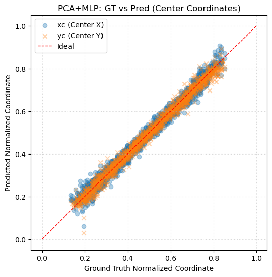

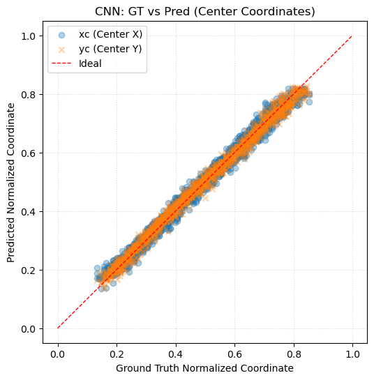

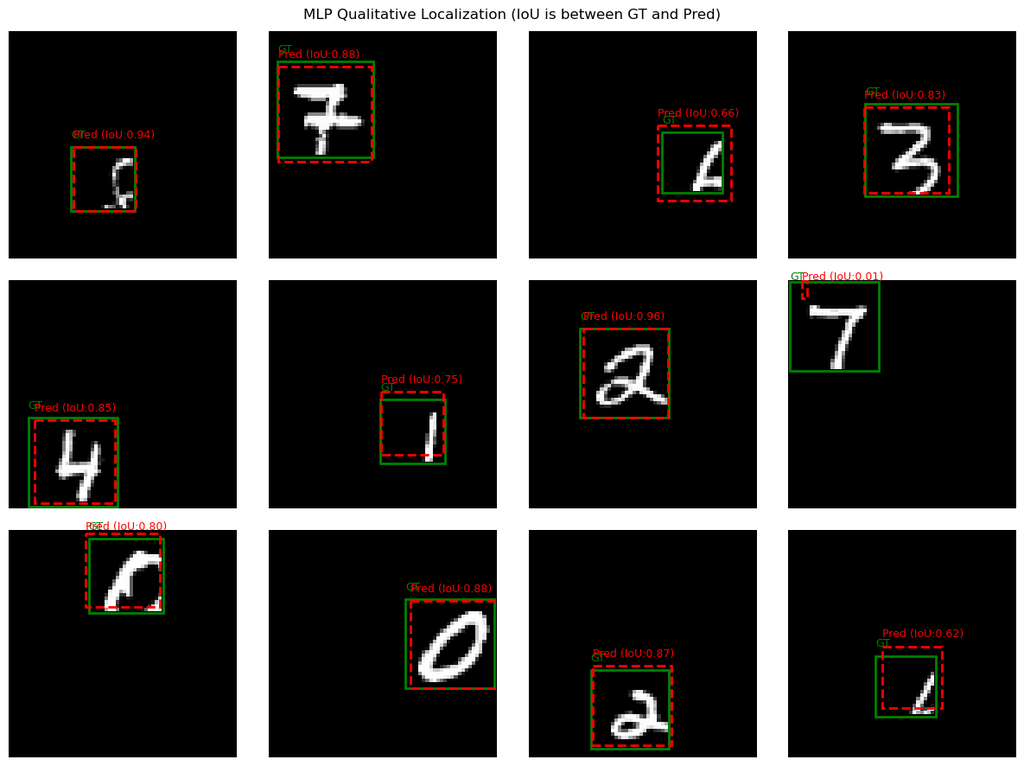

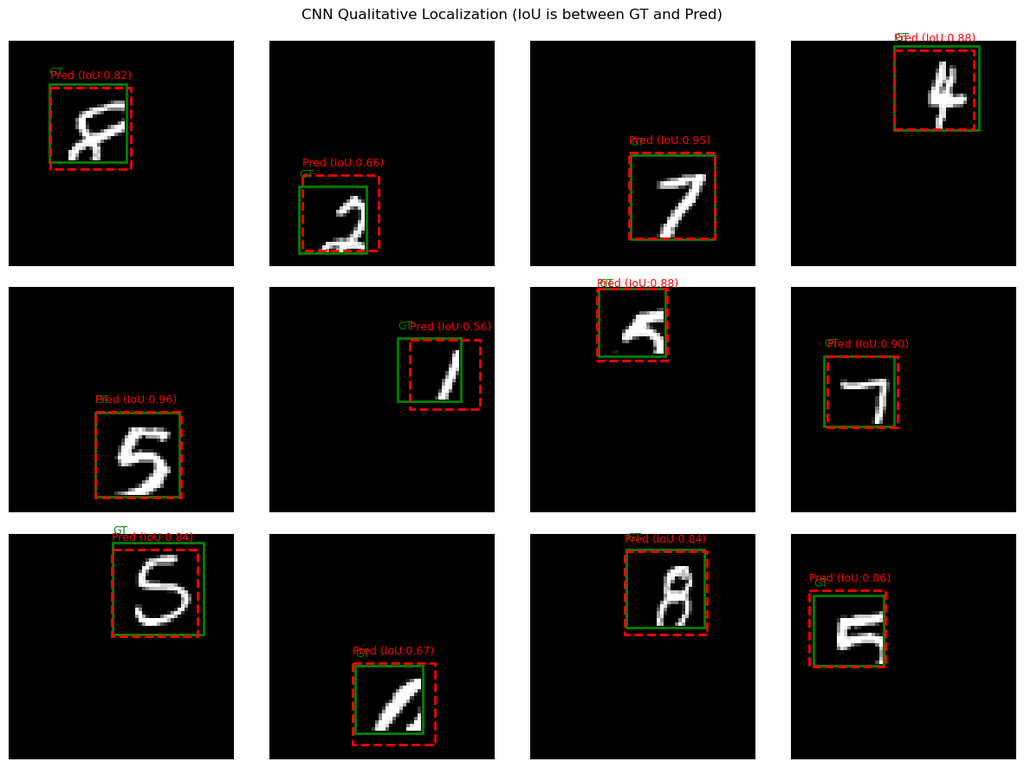

```python
def scatter_gt_vs_pred(G, P, title):
    """ Visualization 1: Scatter plot of Ground Truth vs. Predicted values. """
    plt.figure(figsize=(6, 6))
    plt.scatter(G[:, 0], P[:, 0], alpha=0.35, label="xc (Center X)", marker="o")
    plt.scatter(G[:, 1], P[:, 1], alpha=0.35, label="yc (Center Y)", marker="x")
    plt.plot([0, 1], [0, 1], 'r--', linewidth=1, label="Ideal")
    plt.xlabel("Ground Truth Normalized Coordinate")
    plt.ylabel("Predicted Normalized Coordinate")
    plt.title(title)
    plt.legend()
    plt.grid(True, linestyle=':', alpha=0.5)
    plt.show()

def draw_bbox(ax, bbox_xyxy_norm, H=64, W=64, label="Pred", color='r', linestyle='-'):
    """ Helper to draw a single bounding box on a matplotlib axis. """
    x1, y1, x2, y2 = bbox_xyxy_norm
    x1p, y1p = x1 * W, y1 * H
    wp, hp = (x2 - x1) * W, (y2 - y1) * H
    rect = plt.Rectangle((x1p, y1p), wp, hp, fill=False, linewidth=2, color=color, linestyle=linestyle)
    ax.add_patch(rect)
    ax.text(x1p, max(0, y1p - 2), label, fontsize=9, va="bottom", color=color)


@torch.no_grad()
def visualize_predictions(model, X_images, Z_features, y_true, device, model_type, n=12):
    """ Visualization 2: Qualitative visualization of BBox predictions on test images. """
    model.eval()
    idxs = np.random.choice(len(X_images), size=min(n, len(X_images)), replace=False)

    ncols = 4
    nrows = int(np.ceil(len(idxs) / ncols))
    plt.figure(figsize=(12, 3 * nrows))

    for i, idx in enumerate(idxs, start=1):
        img = X_images[idx, 0]
        gt = y_true[idx]

        if model_type == 'MLP':
            # Use PCA features Z for MLP
            data = torch.from_numpy(Z_features[idx:idx+1]).float().to(device)
        else:
            # Use raw image X for CNN
            data = torch.from_numpy(X_images[idx:idx+1]).float().to(device)

        pred = model(data).cpu().numpy()[0]

        gt_xyxy = bbox_xywh_to_xyxy(gt[None])[0]
        pr_xyxy = bbox_xywh_to_xyxy(pred[None])[0]
        iou = compute_iou(gt_xyxy[None], pr_xyxy[None])[0]

        ax = plt.subplot(nrows, ncols, i)
        ax.imshow(img, cmap="gray")
        draw_bbox(ax, gt_xyxy, label="GT", color='g', linestyle='-')
        draw_bbox(ax, pr_xyxy, label=f"Pred (IoU:{iou:.2f})", color='r', linestyle='--')
        ax.axis("off")

    plt.suptitle(f"{model_type} Qualitative Localization (IoU is between GT and Pred)")
    plt.tight_layout()
    plt.show()


# Run all visualizations


scatter_gt_vs_pred(mlp_G, mlp_P, "PCA+MLP: GT vs Pred (Center Coordinates)")
scatter_gt_vs_pred(cnn_G, cnn_P, "CNN: GT vs Pred (Center Coordinates)")

visualize_predictions(mlp, Xts, Zts, yts, device, model_type='MLP', n=12)
visualize_predictions(cnn, Xts, None, yts, device, model_type='CNN', n=12)
```